# Progress Report paccmann_gp

**Aim of project:** use Bayesian Optimisation with GP processes to optimise the sampling of the SVAE latent space in order to generate smiles which are optimised for specific criteria.

**Week 1 summary:**

- Created a minimization function for the following criteria: target molecular weight, SA score and QED
- Poor results (see below for optimisation for MW close to 100 and for MW close to 700)

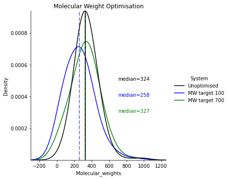

- Assessed if changing sampling method improved results (change the temperature value of the samplingsearch)
- No drastic improvement by changing sampling method

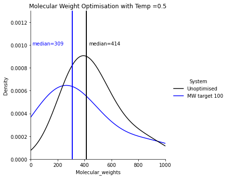

**Week 2 summary:**

- Adjusted the code to sample a batch of smiles for each latent point during the optimisation process
- Studied the effect of evaluating a batch of smiles instead of a single smile for each latent point assessed during the optimisation process
- Evaluating a batch of 30 smiles per latent point leads to a substantially better optimisation
- Studied the effect of increased the number of points evaluated to n_calls=200 (increased eval condition)

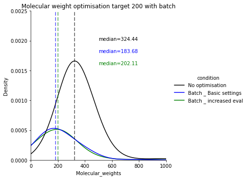

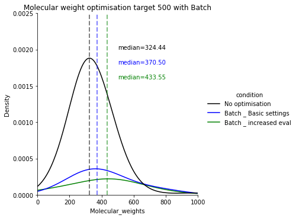

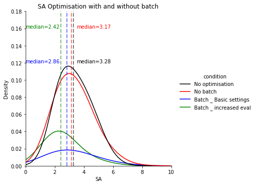

**Week 3 summary:**

- Studied Affinity optimisation

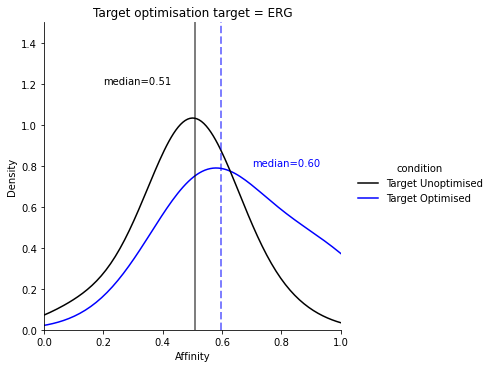

- Created a combined minimisation function: worked for affinity but not qed

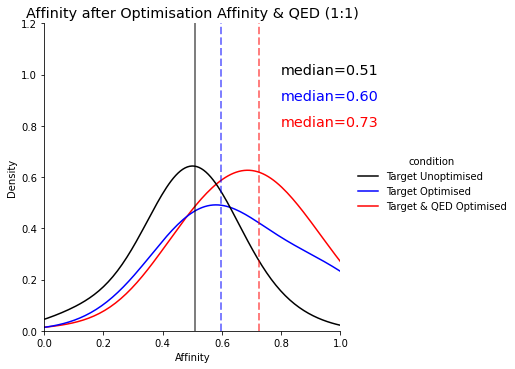

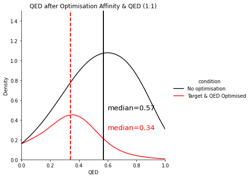

- Studied the effect of optimising for a combination of different criteria scaled with different ratios
- Did not work for the QED optimisation due to code error which led to qed minimisation being ignored

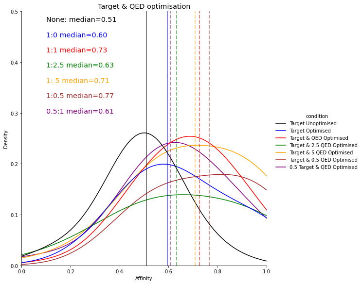

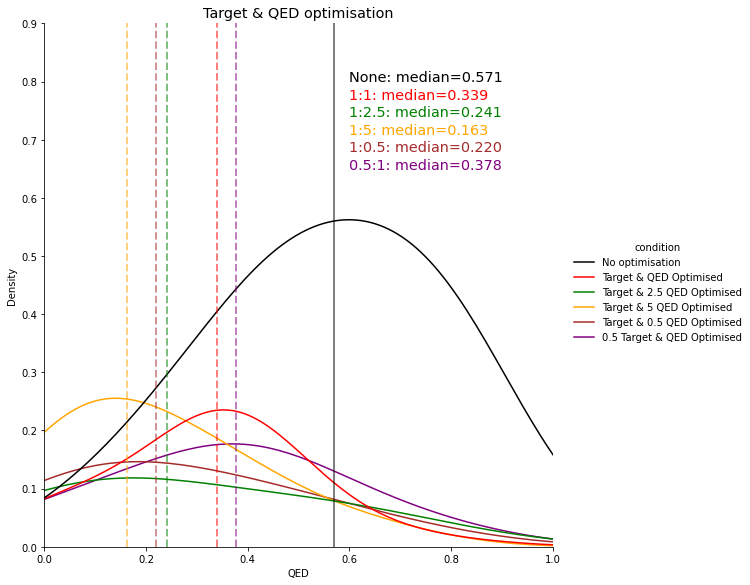

**Week 4 summary:**

- Fixed code to enable the optimisation for a combination of different criteria
- Continued studying the effect of optimising for a combination of different criteria
- The results are encouraging but it appears that a large value of n_calls is required

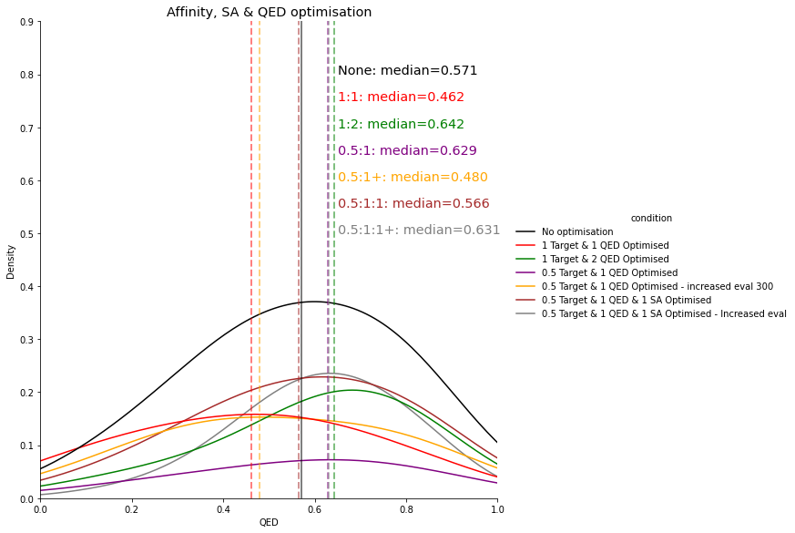

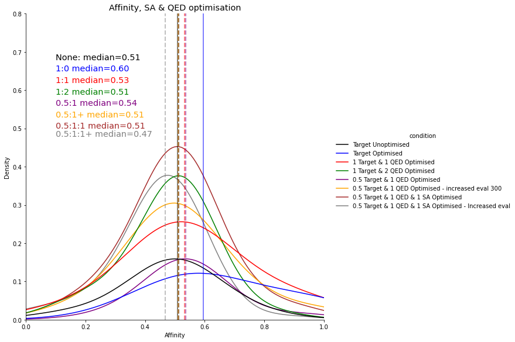

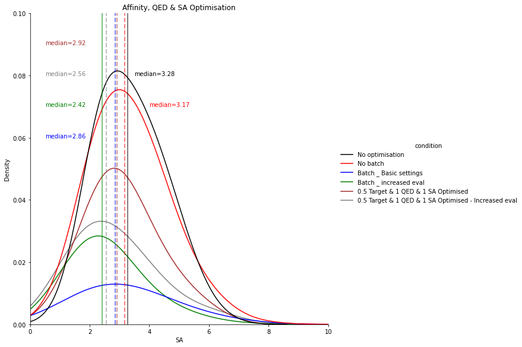

## Appendix - Week 1

**Files created:**

- Environment (conda.yml)
- Generator file/class (smiles_generator.py): created valid smiles from latent represention
- Optimization file/class (gp_optimizer.py): GP optimization
- Minimization function for MW (mw_minization.py): minimize abs(target-MW)
- Minimization function for SA (sa_minization.py): minimize sa_score
- Minimization function for QED (qed_minization.py): minimize 1-qed

**Evaluation method:**

- Select 10 points in latent space (randomly or through optimisation)
- For each point generate 25 smiles structures
- Analyse distribution of e.g. MW of points and shift in median

**Testing:**

- basic conditions: MW minization with two target MW + SA optimization

```
params=dict(dimensions=[(-5.0, 5.0)]*256,
            acq_func="EI",
            n_calls=100,
            n_initial_points=20,
            initial_point_generator='random',
            random_state=1234)
```

- Increase n_calls to 150
- Tried changing Temperature
- Tried different search methods to generate smiles

#### Imports

```python
import matplotlib.pyplot as plt
from statistics import mean, median
import seaborn as sns
import pandas as pd
from IPython.display import Image
```

#### File loading

```python
def file_loading_format_mw_qed_sa(files):
    molecular_weights=[]
    qed_scores=[]
    sa_scores=[]
    for file in files:
        with open(file, 'r') as f:
            f.readline()
            for line in f:
                row = line.split()
                molecular_weights.append(float(row[1]))
                qed_scores.append(float(row[2]))
                sa_scores.append(float(row[3]))
    return molecular_weights, qed_scores, sa_scores
```

Unoptimised files

```python
files_unoptimised_sampling = ['smiles_generated/unoptimised_point_'+str(i+1)+'.txt' for i in range(10)]
```

```python
files_unoptimised_sampling2 = ['smiles_generated/V2unoptimised_point_'+str(i+1)+'.txt' for i in range(10)]
```

```python
#SAMPLING search T=0.5
files_unoptimised_sampling_t05 = ['smiles_generated/T05_unoptimised_point_'+str(i+1)+'.txt' for i in range(10)]
```

```python
#SAMPLING search T=0.1
files_unoptimised_sampling_t01 = ['smiles_generated/T01_unoptimised_point_'+str(i+1)+'.txt' for i in range(10)]
```

```python
#SAMPLING search T=2
files_unoptimised_sampling_t2 = ['smiles_generated/T2_unoptimised_point_'+str(i+1)+'.txt' for i in range(10)]
```

Files optimised for Molecular weight = 100

```python
files_mw100optimised_sampling = ['smiles_generated/MW100optimised_point_'+str(i+1)+'.txt' for i in range(10)]
```

```python
#SAMPLING search T=0.5
files_mw100optimised_sampling_t05 = ['smiles_generated/T05MW100optimised_point_'+str(i+1)+'.txt' for i in range(10)]
```

```python
# For increased n_point=150
files_mw100optimised_sampling_n150 = ['smiles_generated/2MW100optimised_point_'+str(i+1)+'.txt' for i in range(5)]
```

```python
files100V2=[]
for i in range(10):
    files100V2.append('V2MW100optimised_point_'+str(i+1)+'.txt')
```

Files optimised for Molecular weight = 700

```python
files_mw700optimised_sampling = ['smiles_generated/MW700optimised_point_'+str(i+1)+'.txt' for i in range(10)]
```

Files optimised for SA_score

```python
files_sa_optimised_sampling = ['smiles_generated/SAoptimised_point_'+str(i+1)+'.txt' for i in range(10)]
```

```python
# Points for n_point = 100: 10 repeats of optimisation and for each optimised latent point 25 smiles
points = ['point 1']*25+(['point 2']*25)+(['point 3']*25)+(['point 4']*25)+(['point 5']*25)+(['point 6']*25)+(['point 7']*25)+(['point 8']*25)+(['point 9']*25)+(['point 10']*25)
```

```python
# Points for n_point = 150: 5 repeats of optimisation and for each optimised latent point 10 smiles
points2 = ['point 1']*10+(['point 2']*10)+(['point 3']*10)+(['point 4']*10)+(['point 5']*10)
```

Unoptimised data

```python
mw_unopt, qed_unopt, sa_unopt = file_loading_format_mw_qed_sa(files_unoptimised_sampling)
```

```python
dat_unopt_sampling = pd.DataFrame({'Molecular_weights': mw_unopt, 'QED': qed_unopt,'SA': sa_unopt, 'point': points})
```

```python
mw_unopt2, qed_unopt2, sa_unopt2 = file_loading_format_mw_qed_sa(files_unoptimised_sampling2)
```

```python
dat_unopt_sampling2 = pd.DataFrame({'Molecular_weights': mw_unopt2, 'QED': qed_unopt2,'SA': sa_unopt2, 'point': points})#dat2=pd.DataFrame({'Molecular_weights': MWs2, 'QED': QEDs2,'SA':SAS2,'point':points})
```

```python
#MWs3,QEDs3, SAS3 =file_loading(files3)
```

```python
#dat3=pd.DataFrame({'Molecular_weights': MWs3, 'QED': QEDs3,'SA':SAS3,'point':points})
```

```
Sampling Search T=0.1
```

```python
mw_unopt_t01, qed_unopt_t01, sa_unopt_t01 = file_loading_format_mw_qed_sa(files_unoptimised_sampling_t01)
```

```python
dat_unopt_t01 = pd.DataFrame({'Molecular_weights': mw_unopt_t01, 'QED': qed_unopt_t01,'SA': sa_unopt_t01,'point': points})
```

```
Sampling search T=0.5
```

```python
mw_unopt_t05, qed_unopt_t05, sa_unopt_t05 = file_loading_format_mw_qed_sa(files_unoptimised_sampling_t05)
```

```python
dat_unopt_t05 = pd.DataFrame({'Molecular_weights': mw_unopt_t05, 'QED': qed_unopt_t05,'SA': sa_unopt_t05,'point': points})
```

```
Sampling search T=2
```

```python
mw_unopt_t2, qed_unopt_t2, sa_unopt_t2 = file_loading_format_mw_qed_sa(files_unoptimised_sampling_t2)
```

```python
dat_unopt_t2 = pd.DataFrame({'Molecular_weights': mw_unopt_t2, 'QED': qed_unopt_t2,'SA': sa_unopt_t2,'point': points})
```

```
Combine all data for different temperatures of sampling
```

```python
dat_t_evaluation = pd.DataFrame({'Molecular_weights': mw_unopt2+mw_unopt_t01+mw_unopt_t05+mw_unopt_t2, 'QED': qed_unopt2+qed_unopt_t01+qed_unopt_t05+qed_unopt_t2,'SA':sa_unopt2+sa_unopt_t01+sa_unopt_t05+sa_unopt_t2,'point':points*4,'System':['Temp=1']*250+(['Temp=0.1']*250)+(['Temp=0.5']*250)+(['Temp=2']*250)})
```

Optimised MW target 100 data

```python
mw_mw100, qed_mw100, sa_mw100 = file_loading_format_mw_qed_sa(files_mw100optimised_sampling)
```

```python
dat_mw100 = pd.DataFrame({'Molecular_weights': mw_mw100, 'QED': qed_mw100,'SA': sa_mw100, 'point':points})
```

```python
MWs100V2,QEDs100V2,SAS100V2=file_loading(files100V2)
```

```python
dat100V2=pd.DataFrame({'Molecular_weights': MWsV2+MWs100V2, 'QED': QEDsV2+QEDs100V2,'SA':SASV2+SAS100V2,'System':['Unoptimised']*250+(['MW target 100']*250),'point':points*2})
```

```python
datMW100V2=dat100V2.loc[250:]
```

```
T=0.5
```

```python
mw_mw100_t05, qed_mw100_t05, sa_mw100_t05 = file_loading_format_mw_qed_sa(files_mw100optimised_sampling_t05)
```

```python
dat_mw100_t05_comb=pd.DataFrame({'Molecular_weights': mw_unopt_t05+mw_mw100_t05, 'QED': qed_unopt_t05+qed_mw100_t05,'SA':sa_unopt_t05+sa_mw100_t05,'System':['Unoptimised']*250+(['MW target 100']*250),'point':points*2})
```

```python
dat_mw100_t05=dat_mw100_t05_comb.loc[250:]
```

```
with n_calls=150
```

```python
mw_mw100_n150, qed_mw100_n150, sa_mw100_n150 = file_loading_format_mw_qed_sa(files_mw100optimised_sampling_n150)
```

```python
dat_mw100_n150 = pd.DataFrame({'Molecular_weights': mw_mw100_n150, 'QED': qed_mw100_n150,'SA': sa_mw100_n150, 'point':points2})
```

Optimised MW target 700 data

```python
mw_mw700, qed_mw700, sa_mw700 = file_loading_format_mw_qed_sa(files_mw700optimised_sampling)
```

```python
dat_mw700 = pd.DataFrame({'Molecular_weights': mw_mw700, 'QED': qed_mw700, 'SA': sa_mw700, 'point':points})
```

Combined unoptimised, MW target 100 and MW target 700

```python
dat_mw_comb = pd.DataFrame({'Molecular_weights': mw_unopt+mw_mw100+mw_mw700, 'QED': qed_unopt+qed_mw100+qed_mw700,'SA':sa_unopt+sa_mw100+sa_mw700,'System':['Unoptimised']*250+(['MW target 100']*250)+(['MW target 700']*250),'point':points*3})
```

SA optimised data

```python
mw_sa, qed_sa, sa_sa = file_loading_format_mw_qed_sa(files_sa_optimised_sampling)
```

```python
dat_sa_comb=pd.DataFrame({'Molecular_weights': mw_unopt+mw_sa, 'QED': qed_unopt+qed_sa,'SA':sa_unopt+sa_sa,'System':['Unoptimised']*250+(['SA optimised']*250),'point':points*2})
```

```python
dat_sa=dat_sa_comb.loc[250:]
```

### 1: Optimisation with basic settings

```
params=dict(dimensions=[(-5.0, 5.0)]*256,
            acq_func="EI",
            n_calls=100,
            n_initial_points=20,
            initial_point_generator='random',
            random_state=1234)
```

#### 1.A: MW optimisation (2 targets)

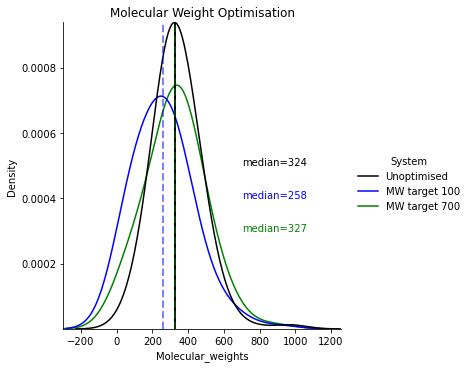

```python
sns.displot(dat_mw_comb, kind='kde',x='Molecular_weights',hue='System',bw_adjust=2,palette=['k','b','g'])
plt.axvline(x=dat_unopt_sampling.Molecular_weights.median(), linewidth=2, color='k' )
plt.text(700,0.0005,'median='+str("%.0f"%dat_unopt_sampling.Molecular_weights.median()))
plt.axvline(x=dat_mw100.Molecular_weights.median(), linewidth=2, color='b', linestyle='--' , alpha=0.5)
plt.text(700,0.0004,'median='+str("%.0f"%dat_mw100.Molecular_weights.median()),color='b')
plt.axvline(x=dat_mw700.Molecular_weights.median(), linewidth=2, color='g' , linestyle='--', alpha=0.5)
plt.text(700,0.0003,'median='+str("%.0f"%dat_mw700.Molecular_weights.median()),color='g')
plt.ylim(0, 0.0011)
plt.xlim(0, 1000)
plt.title('Molecular Weight Optimisation')
plt.autoscale(tight=True)
plt.savefig('week1.png', bbox_inches='tight', )
```

**Conclusion:**

- Small decrease in MW of smiles generated from optimised latent point for MW target 100 but the median MW is not 100
- No observable difference for optimisation with target MW 700
- Thoughts: MW700 optmisation is likely limited by limit on smiles length of 100

##### Histogram distribution graphs

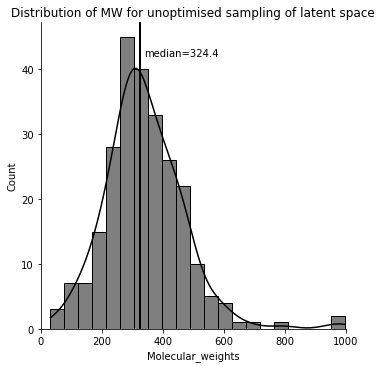

```python
sns.displot(dat_unopt_sampling, kde=True,x='Molecular_weights',color='k')
plt.axvline(x=dat_unopt_sampling.Molecular_weights.median(), linewidth=2, color='k')
plt.text(340,42,'median='+str("%.1f"%dat_unopt_sampling.Molecular_weights.median()))
plt.xlim(0, 1000)
plt.title('Distribution of MW for unoptimised sampling of latent space')
```

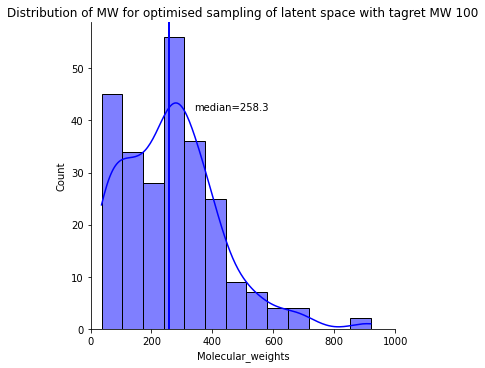

```python
sns.displot(dat_mw100, kde=True,x='Molecular_weights',color='b')
plt.axvline(x=dat_mw100.Molecular_weights.median(), linewidth=2, color='b')
plt.text(340,42,'median='+str("%.1f"%dat_mw100.Molecular_weights.median()))
plt.xlim(0, 1000)
plt.title('Distribution of MW for optimised sampling of latent space with tagret MW 100')
```

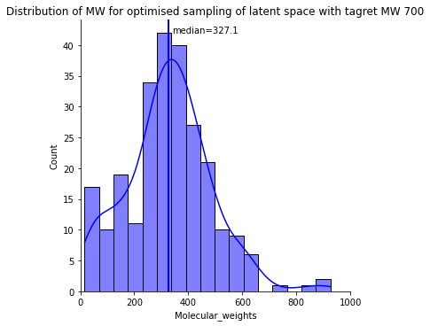

```python
sns.displot(dat_mw700, kde=True,x='Molecular_weights',color='b')
plt.axvline(x=dat_mw700.Molecular_weights.median(), linewidth=2, color='b')
plt.text(340,42,'median='+str("%.1f"%dat_mw700.Molecular_weights.median()))
plt.xlim(0, 1000)
plt.title('Distribution of MW for optimised sampling of latent space with tagret MW 700')
```

##### Distribution per point

[figure not shown]

```python
sns.displot(dat_unopt_sampling, kind='kde',x='Molecular_weights',hue='point',bw_adjust=2)
plt.xlim(0, 1000)
plt.title('MW distribution per point for unoptimised sampling')
```

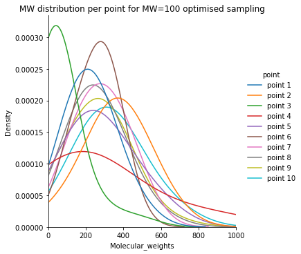

```python
sns.displot(dat_mw100, kind='kde',x='Molecular_weights',hue='point',bw_adjust=2)
plt.xlim(0, 1000)
plt.title('MW distribution per point for MW=100 optimised sampling')
```

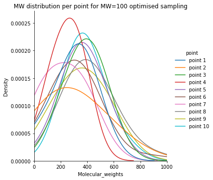

```python
sns.displot(dat_mw700, kind='kde',x='Molecular_weights',hue='point',bw_adjust=2)
plt.xlim(0, 1000)
plt.title('MW distribution per point for MW=100 optimised sampling')
```

##### Changes in other parameters after MW optimisation

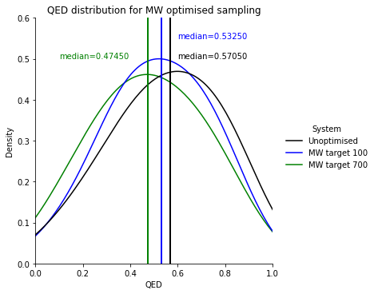

```python
sns.displot(dat_mw_comb, kind='kde',x='QED',hue='System',bw_adjust=2,palette=['k','b','g'])
plt.axvline(x=dat_unopt_sampling.QED.median(), linewidth=2, color='k' )
plt.text(0.6,0.5,'median='+str("%.05f"%dat_unopt_sampling.QED.median()))
plt.axvline(x=dat_mw100.QED.median(), linewidth=2, color='b' )
plt.text(0.6,0.55,'median='+str("%.05f"%dat_mw100.QED.median()),color='b')
plt.xlim(0, 1)
plt.axvline(x=dat_mw700.QED.median(), linewidth=2, color='g' )
plt.text(0.1,0.5,'median='+str("%.05f"%dat_mw700.QED.median()),color='g')
plt.ylim(0, 0.6)
plt.title('QED distribution for MW optimised sampling')
```

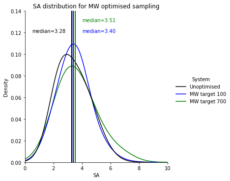

```python
sns.displot(dat_mw_comb, kind='kde',x='SA',hue='System',bw_adjust=2,palette=['k','b','g'])
plt.axvline(x=dat_unopt_sampling.SA.median(), linewidth=2, color='k' )
plt.text(0.5,0.12,'median='+str("%.02f"%dat_unopt_sampling.SA.median()))
plt.axvline(x=dat_mw100.SA.median(), linewidth=2, color='b' )
plt.text(4,0.12,'median='+str("%.02f"%dat_mw100.SA.median()),color='b')
plt.xlim(0, 10)
plt.axvline(x=dat_mw700.SA.median(), linewidth=2, color='g' )
plt.text(4,0.13,'median='+str("%.02f"%dat_mw700.SA.median()),color='g')
plt.ylim(0, 0.14)
plt.title('SA distribution for MW optimised sampling')
```

#### 1.B: SA optimisation

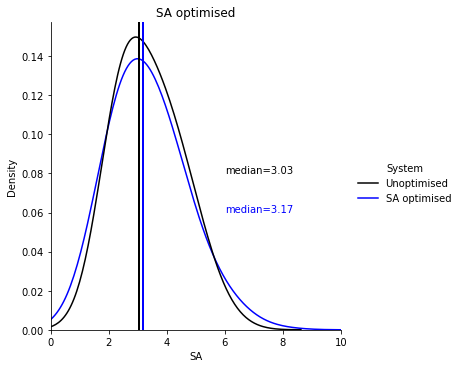

```python
sns.displot(dat_sa_comb, kind='kde',x='SA',hue='System',bw_adjust=2,palette=['k','b'])
plt.axvline(x=dat_unopt_sampling2.SA.median(), linewidth=2, color='k' )
plt.text(6,0.08,'median='+str("%.02f"%dat_unopt_sampling2.SA.median()))
plt.axvline(x=dat_sa.SA.median(), linewidth=2, color='b' )
plt.text(6,0.06,'median='+str("%.02f"%dat_sa.SA.median()),color='b')
plt.xlim(0, 10)
plt.title('SA optimised')
```

**Conclusion:**

- No large shift in median SA value with SA optimisation: shift is not even in right direction

##### Distribution of each point (optimisation repeat)

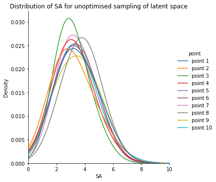

```python
sns.displot(dat_unopt_sampling, kind='kde',x='SA',hue='point',bw_adjust=2)
plt.xlim(0, 10)
plt.title('Unoptimised')
plt.title('Distribution of SA for unoptimised sampling of latent space')
```

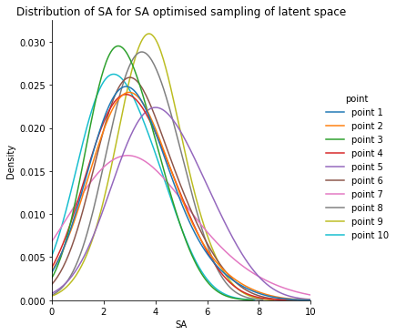

```python
sns.displot(dat_sa, kind='kde',x='SA',hue='point',bw_adjust=2)
plt.xlim(0, 10)
plt.title('Distribution of SA for SA optimised sampling of latent space')
```

### 2: Optimisation increased n_calls: 150

```
params=dict(dimensions=[(-5.0, 5.0)]*256,
            acq_func="EI",
            n_calls=150,
            n_initial_points=20,
            initial_point_generator='random',
            random_state=1234)
```

!!! Note less latent points and smiles for each point are evaluated thus distribution of Unoptimised cannot be compared to optimised case distribution --> **Look at median values not distributions**

```python
print('Median MW without optimisation:', dat_unopt_sampling.Molecular_weights.median())
print('Median MW with optimisation for MW target 100:', dat_mw100.Molecular_weights.median())
print('Median MW with optimisation for MW target 100 with increase n_calls:', dat_mw100_n150.Molecular_weights.median())
```

```
Median MW without optimisation: 324.4425
Median MW with optimisation for MW target 100: 258.3245
Median MW with optimisation for MW target 100 with increase n_calls: 273.28499999999997
```

**Conclusion:**

- Optimisation is not better with increased n_calls

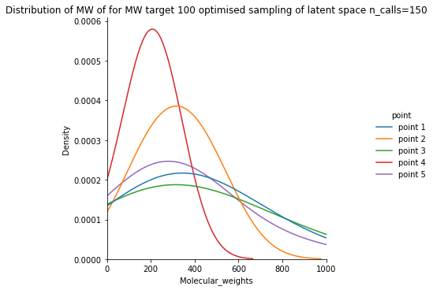

```python
sns.displot(dat_mw100_n150, kind='kde',x='Molecular_weights',hue='point',bw_adjust=2)
plt.xlim(0, 1000)
plt.title('Distribution of MW of for MW target 100 optimised sampling of latent space n_calls=150')
```